# 0. La pregunta: ¿cómo se fija la tasa de una hipoteca?

Modelos No Paramétricos y de Regresión · Caso de estudio: tasas hipotecarias en EE. UU., 2024

## La pregunta

Dos personas piden el mismo crédito para comprar una casa el mismo mes. Una tiene un historial de crédito excelente y la otra uno regular; una llega directo al banco y la otra a través de un **bróker** (un intermediario que compara bancos y cobra por ello). ¿Pagan la misma tasa?

Durante el curso vamos a contestar dos preguntas concretas:

1. **¿Cuánto más paga de tasa un acreditado con peor historial de crédito?**
2. **¿Los brókers cobran más que el banco directo, a igual riesgo?**

La segunda es una pregunta de política pública: si los intermediarios encarecieran el crédito, convendría evitarlos. Contestarla bien obliga a comparar **personas comparables**, que es justo lo que enseña la regresión.

## Los datos

Freddie Mac, una empresa del gobierno de EE. UU. que compra hipotecas a los bancos, publica las características de cada crédito que adquiere. Usamos su **muestra aleatoria de 50,000 hipotecas otorgadas en 2024**. Por cada crédito sabemos, al momento de otorgarlo:

| Variable | Qué es |
| --- | --- |
| Tasa | Tasa de interés anual del crédito (la variable respuesta) |
| FICO | Calificación de crédito del acreditado (300 a 850; más alto = mejor historial) |
| LTV | Préstamo entre valor de la casa, en %. LTV de 80 = puso 20% de enganche |
| DTI | Pagos de deudas entre ingreso, en % |
| Canal | Banco directo, bróker o corresponsal (un banco pequeño que otorga el crédito y lo vende) |
| Propósito | Compra, refinanciamiento o refinanciamiento con retiro de efectivo |
| Mes | Mes del primer pago (refleja cuándo se pactó la tasa) |

> Los datos no están en el repositorio: los términos de Freddie Mac permiten publicar resultados, no los datos. Para reproducir, descárgalos con un registro gratuito (ver README). Ningún capítulo muestra créditos individuales; solo resúmenes y modelos.

Nos quedamos con hipotecas a **30 años** (las de 15 o 20 años tienen otra tasa) y con un periodo de **12 meses completos**: primer pago entre marzo de 2024 y febrero de 2025.

```r
hipotecas <- leer_hipotecas()
c(creditos = nrow(hipotecas), tasa_promedio = mean(hipotecas$tasa), tasa_mediana = median(hipotecas$tasa))
```

```
##      creditos tasa_promedio  tasa_mediana
##  46190.000000      6.735836      6.750000
```

```r
hipotecas |> count(canal) |> mutate(porcentaje = round(100 * n / sum(n), 1))
```

```
## # A tibble: 3 × 3
##   canal             n porcentaje
##   <fct>         <int>      <dbl>
## 1 Banco directo 22091       47.8
## 2 Bróker         7468       16.2
## 3 Corresponsal  16631       36
```

## Un primer vistazo, y por qué no basta

```r
hipotecas |> group_by(canal) |>
  summarise(creditos = n(), tasa_promedio = mean(tasa), fico_promedio = mean(fico), ltv_promedio = mean(ltv))
```

```
## # A tibble: 3 × 5
##   canal         creditos tasa_promedio fico_promedio ltv_promedio
##   <fct>            <int>         <dbl>         <dbl>        <dbl>
## 1 Banco directo    22091          6.74          750.         74.3
## 2 Bróker            7468          6.73          754.         77.7
## 3 Corresponsal     16631          6.73          754.         77.6
```

Los brókers cobran, en promedio, prácticamente lo mismo que el banco directo. ¿Respuesta lista? No. Dos cosas pueden engañar a esta comparación:

- **El mercado se mueve.** La tasa depende mucho de *cuándo* se pactó el crédito, porque las tasas del mercado subieron y bajaron durante 2024. Si los brókers otorgaron más créditos en meses caros o baratos, la comparación se contamina.
- **Los acreditados no son iguales.** Si los clientes de bróker son más riesgosos (por ejemplo, con menos enganche), a igual tasa estarían pagando *menos* por su riesgo.

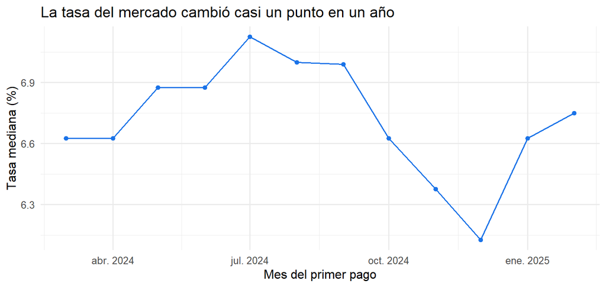

```r
hipotecas |> group_by(mes) |> summarise(tasa = median(tasa)) |>
  ggplot(aes(as.Date(paste0(mes, "01"), "%Y%m%d"), tasa)) +
  geom_line(colour = AZUL) + geom_point(colour = AZUL) +
  labs(x = "Mes del primer pago", y = "Tasa mediana (%)", title = "La tasa del mercado cambió casi un punto en un año")
```

## El plan del curso

| Capítulo | Unidad del temario (clave 1639) | Qué aporta a la respuesta |
| --- | --- | --- |
| 1 | 1. Pruebas no paramétricas | Comparar grupos sin suponer normalidad; revisar la calidad de los datos |
| 2 | 2.1–2.2 Regresión lineal simple | Cuánto cambia la tasa con el FICO, y si la relación es lineal |
| 3 | 2.3–2.4 Regresión múltiple y selección de modelos | Ajustar por todo lo demás a la vez |
| 4 | 2.5–2.6 ANOVA y ANCOVA | La respuesta: ¿los brókers cobran más, a igual riesgo? |
| 5 | Más allá del curso: MANOVA y MANCOVA | ¿Qué tipo de crédito otorga cada canal, considerando tasa, enganche, DTI y monto a la vez? |